# Lab 2 HipHop Lyrics

Stephanie Liu

October 3, 2021

```r
library(tidyverse)
library(prettydoc)
library(here)
```

```r
hiphop <- read_csv(here("Data", "hiphop.csv"))
```

# Assignment

## Summary

**1. Provide a brief overview (2-4 sentences) of the dataset. (It is always good practice to start an analysis by getting a feel for the data and providing a quick summary for readers.) You do not need to show any source code for this question, although you probably want to use code to get information.**

```r
head(hiphop)
```

```
## # A tibble: 6 × 38
##   word  subj  sex     age ethnic   city county  intl vocal classical  folk  rock
##   <chr> <chr> <chr> <dbl> <chr>   <dbl>  <dbl> <dbl> <dbl>     <dbl> <dbl> <dbl>
## 1 [to … p15   Fema…    20 white   33283 1.16e6     0     0         0     0     1
## 2 [to … p53   Fema…    17 white   34033 3.96e5     0     0         0     0     0
## 3 [to … p136  Male     41 white    8789 5.87e4     0     2         0     0     0
## 4 [to … p36   Fema…    18 white     712 1.49e5     0     0         0     1     1
## 5 [to … p118  Fema…    18 white   24280 1.54e5     0     3         3     0     1
## 6 [to … p106  Male     19 white  281262 5.06e5     0     0         0     0     0
## # … with 26 more variables: country <dbl>, pop <dbl>, alternative <dbl>,
## #   hiphop <dbl>, unclassifiable <dbl>, countyBlack <dbl>, jayz <dbl>,
## #   barkley <dbl>, boondocks <dbl>, monique <dbl>, bieber <dbl>,
## #   asianMove <dbl>, blackMove <dbl>, hispanicMove <dbl>, nativeMove <dbl>,
## #   SAAMEMove <dbl>, whiteMove <dbl>, blackWeekly <dbl>, jayz1 <dbl>,
## #   boondocks1 <dbl>, familiarity <dbl>, trial <dbl>, fam1 <dbl>,
## #   popularityScore <dbl>, numPreferredArtists <dbl>, numOverallArtists <dbl>
```

```r
hiphop %>%
  summary()
```

```
##      word               subj               sex                 age
##  Length:10752       Length:10752       Length:10752       Min.   :16.00
##  Class :character   Class :character   Class :character   1st Qu.:18.00
##  Mode  :character   Mode  :character   Mode  :character   Median :19.00
##                                                           Mean   :20.02
##                                                           3rd Qu.:20.00
##                                                           Max.   :48.00
##
##     ethnic               city             county             intl
##  Length:10752       Min.   :      0   Min.   :      0   Min.   : 0.0000
##  Class :character   1st Qu.:  12807   1st Qu.:  99905   1st Qu.: 0.0000
##  Mode  :character   Median :  42322   Median : 331582   Median : 0.0000
##                     Mean   : 159130   Mean   : 509216   Mean   : 0.3869
##                     3rd Qu.: 103486   3rd Qu.: 959521   3rd Qu.: 0.0000
##                     Max.   :8391881   Max.   :3053793   Max.   :15.0000
##
##      vocal          classical            folk             rock
##  Min.   : 0.000   Min.   : 0.0000   Min.   :0.0000   Min.   : 0.000
##  1st Qu.: 0.000   1st Qu.: 0.0000   1st Qu.:0.0000   1st Qu.: 0.000
##  Median : 0.000   Median : 0.0000   Median :0.0000   Median : 1.000
##  Mean   : 1.089   Mean   : 0.8095   Mean   :0.3988   Mean   : 2.274
##  3rd Qu.: 1.000   3rd Qu.: 0.0000   3rd Qu.:0.0000   3rd Qu.: 4.000
##  Max.   :11.000   Max.   :10.0000   Max.   :6.0000   Max.   :18.000
##
##     country            pop          alternative         hiphop
##  Min.   :0.0000   Min.   : 0.000   Min.   : 0.000   Min.   : 0.000
##  1st Qu.:0.0000   1st Qu.: 0.000   1st Qu.: 0.000   1st Qu.: 0.000
##  Median :0.0000   Median : 1.000   Median : 2.000   Median : 0.000
##  Mean   :0.6667   Mean   : 1.238   Mean   : 2.196   Mean   : 1.595
##  3rd Qu.:0.0000   3rd Qu.: 2.000   3rd Qu.: 4.000   3rd Qu.: 3.000
##  Max.   :7.0000   Max.   :11.000   Max.   :13.000   Max.   :10.000
##
##  unclassifiable     countyBlack          jayz          barkley
##  Min.   :0.00000   Min.   :     0   Min.   :1.000   Min.   :1.000
##  1st Qu.:0.00000   1st Qu.:   675   1st Qu.:1.000   1st Qu.:1.000
##  Median :0.00000   Median :  7748   Median :5.000   Median :1.000
##  Mean   :0.05357   Mean   : 46404   Mean   :3.839   Mean   :1.804
##  3rd Qu.:0.00000   3rd Qu.: 50842   3rd Qu.:5.000   3rd Qu.:3.000
##  Max.   :1.00000   Max.   :942470   Max.   :5.000   Max.   :5.000
##
```

[output cut: 25 more lines]

```
##  Min.   :1.000   Min.   : 1.00   Min.   :0.00   Min.   :  0.00
##  1st Qu.:1.000   1st Qu.:16.75   1st Qu.:0.00   1st Qu.:  0.00
##  Median :1.000   Median :32.50   Median :0.00   Median : 21.00
##  Mean   :1.818   Mean   :32.50   Mean   :0.24   Mean   : 27.64
##  3rd Qu.:1.000   3rd Qu.:48.25   3rd Qu.:0.00   3rd Qu.: 42.50
##  Max.   :5.000   Max.   :64.00   Max.   :1.00   Max.   :120.00
##
##  numPreferredArtists numOverallArtists
##  Min.   :0.000       Min.   : 0.000
##  1st Qu.:0.000       1st Qu.: 0.000
##  Median :0.000       Median : 3.000
##  Mean   :0.338       Mean   : 5.953
##  3rd Qu.:0.000       3rd Qu.: 8.000
##  Max.   :6.000       Max.   :28.000
##  NA's   :5632        NA's   :5632
```

There are 38 variables in the hiphop dataset, and 10752 entries. The variables `word`, `subject`, `sex` and `ethnic` are all characters, and the rest of the variables are numeric. `word` represents a AAE term that the 168 subjects were asked about. The corresponding data for each line represents information about each subject and their responses to each word.

**2. Clean the dataset in whichever ways you see fit. This might mean adjusting variable type, for example from “character” to “factor”, or dealing with missing data.**

```r
# note there are NAs in the numPreferredArtists and numOverallArtists,
# we will most likely not use these variables for this assignment, so I'm deleting them
hiphop <- hiphop %>%
  select(-c(numPreferredArtists, numOverallArtists))
```

**3. How many unique AAVE words were studied in this dataset?**

```r
hiphop %>%
  select(word) %>%
  unique() %>%
  count()
```

```
## # A tibble: 1 × 1
##       n
##   <int>
## 1    64
```

There are 64 unique AAVE words in this dataset.

**4. Make a new variable that recategorizes ethnic into only two groups, “white” and “non-white”, to simplify your data.**

*Helpful functions: mutate(), case_when()*

```r
hiphop <- hiphop %>%
  mutate(two_ethnic = case_when(ethnic == "white" ~ "white",
                            ethnic != "white" ~ "non-white")
  )
```

**5. What are the demographics of the people in this study? Investigate the variables sex, age, and ethnic and summarize your findings in 1-3 complete sentences.**

*Hint: What are the rows of this dataset? It is not one person per row! You’ll need to first manipulate your data to have each person represented only once.*

*Helpful functions: select(), unique() or distinct(, .keep_all = TRUE), count(), summary()*

```r
hiphop_demo <- hiphop %>%
  select(subj, sex, age, ethnic) %>%
  unique() %>%
  arrange(desc(age))

hiphop_demo %>%
  select(age) %>%
  summary()
```

```
##       age
##  Min.   :16.00
##  1st Qu.:18.00
##  Median :19.00
##  Mean   :20.02
##  3rd Qu.:20.00
##  Max.   :48.00
```

```r
hiphop_demo %>%
  select(subj, ethnic) %>%
  unique() %>%
  count(ethnic)
```

```
## # A tibble: 9 × 2
##   ethnic       n
##   <chr>    <int>
## 1 african      5
## 2 asian       19
## 3 biracial     1
## 4 black        1
## 5 hispanic     3
## 6 indian       2
## 7 native       1
## 8 unknown      1
## 9 white      135
```

```r
hiphop_demo %>%
  select(subj, sex) %>%
  unique() %>%
  count(sex)
```

```
## # A tibble: 2 × 2
##   sex        n
##   <chr>  <int>
## 1 Female   117
## 2 Male      51
```

```r
# note that we can also do the following to get the same result:
hiphop_demo %>%
  select(subj, sex) %>%
  group_by(sex) %>%
  count(sex)
```

```
## # A tibble: 2 × 2
## # Groups:   sex [2]
##   sex        n
##   <chr>  <int>
## 1 Female   117
## 2 Male      51
```

There are 168 subjects/people in this dataset. The youngest person is 16, the oldest person is 48 and the mean age is 20.02 years. There are 9 different ethnicities listed: African (5 people), Asian (19 people), Biracial (1 person), Black (1 person), Hispanic (3 people), Indian (2 people), Native (1 person), Unknown (1 person), White (135 people). There are 117 females and 51 males.

**6. Make at least two plots to display the demographic information of the subjects in this study. You do not need to discuss these plots, but make sure they are appropriate to the data types and have informative titles and axis labels.**

*Functions: ggplot(), geom_histogram(), geom_boxplot(), geom_bar(), ggtitle(), xlab(), ylab()*

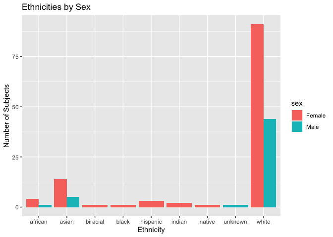

```r
hiphop_demo %>%
  ggplot() +
  geom_bar(aes(x = ethnic, fill = sex), position = "dodge") +
  ggtitle("Ethnicities by Sex") +
  xlab("Ethnicity") +
  ylab("Number of Subjects")
```

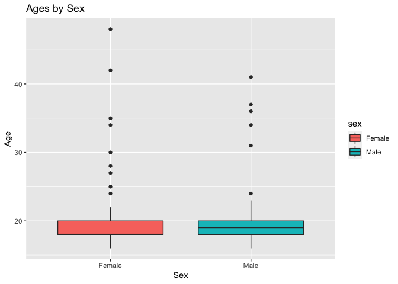

```r
hiphop_demo %>%
  ggplot() +
  geom_boxplot(aes(x = sex, y = age, fill = sex)) +
  ggtitle("Ages by Sex") +
  xlab("Sex") +
  ylab("Age")
```

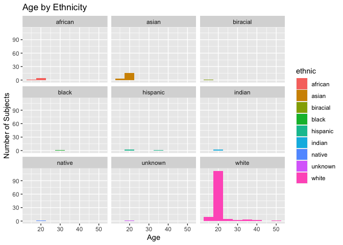

```r
# note that this plot is not as helpful, since some ethnicities only have one subject assigned to them.
hiphop_demo %>%
  ggplot() +
  geom_histogram(aes(x = age, fill = ethnic), bins = 15, binwidth = 5) +
  facet_wrap(~ethnic) +
  ggtitle("Age by Ethnicity") +
  xlab("Age") +
  ylab("Number of Subjects")
```

## Familiar words

**1. For each demographic group listed below, determine which word(s) in this study was the most and least familiar on average.**

*Helpful functions: filter(), arrange(), desc(), top_n()*

**People below the age of 20**

```r
hiphop %>%
  select(word, age, familiarity) %>%
  filter(age < 20) %>%
  group_by(word) %>%
  summarise(avg_word_fam = mean(familiarity)) %>%
  arrange(desc(avg_word_fam)) %>%
  top_n(5)
```

```
## # A tibble: 5 × 2
##   word         avg_word_fam
##   <chr>               <dbl>
## 1 off the hook         4.42
## 2 feel me              4.27
## 3 hella                3.73
## 4 boo                  3.69
## 5 what it do           3.01
```

```r
hiphop %>%
  select(word, age, familiarity) %>%
  filter(age < 20) %>%
  group_by(word) %>%
  summarise(avg_word_fam = mean(familiarity)) %>%
  arrange(desc(avg_word_fam)) %>%
  top_n(-5)
```

```
## # A tibble: 5 × 2
##   word             avg_word_fam
##   <chr>                   <dbl>
## 1 face gator               1.10
## 2 rollie                   1.10
## 3 The Nation               1.04
## 4 domino                   1.03
## 5 catch the vapors         1.03
```

For people below the age of 20, the phrase “off the hook” was most familiar, and the phrase “catch the vapors” was least familiar.

**Non-white women**

```r
hiphop %>%
  select(word, two_ethnic, sex, familiarity) %>%
  filter(two_ethnic == "non-white") %>%
  filter(sex == "Female") %>%
  group_by(word) %>%
  summarise(avg_word_fam = mean(familiarity)) %>%
  arrange(desc(avg_word_fam)) %>%
  top_n(5)
```

```
## # A tibble: 5 × 2
##   word         avg_word_fam
##   <chr>               <dbl>
## 1 feel me              4.19
## 2 boo                  3.77
## 3 off the hook         3.54
## 4 what it do           3.23
## 5 hella                3.15
```

```r
hiphop %>%
  select(word, two_ethnic, sex, familiarity) %>%
  filter(two_ethnic == "non-white") %>%
  filter(sex == "Female") %>%
  group_by(word) %>%
  summarise(avg_word_fam = mean(familiarity)) %>%
  arrange((avg_word_fam)) %>%
  top_n(-5)
```

```
## # A tibble: 5 × 2
##   word              avg_word_fam
##   <chr>                    <dbl>
## 1 break someone out         1
## 2 dukey rope                1
## 3 plex                      1
## 4 rollie                    1
## 5 The Nation                1.04
```

For non-white women, the most familiar phrase was “feel me”, and the least familiar phrase was “break someone out”.

**White men above the age of 30**

```r
hiphop %>%
  select(word, ethnic, sex, age, familiarity) %>%
  filter(ethnic == "white") %>%
  filter(sex == "Male") %>%
  filter(age > 30) %>%
  group_by(word) %>%
  summarise(avg_word_fam = mean(familiarity)) %>%
  arrange(desc(avg_word_fam)) %>%
  top_n(5)
```

```
## # A tibble: 6 × 2
##   word            avg_word_fam
##   <chr>                  <dbl>
## 1 5-0                      4.2
## 2 feel me                  4
## 3 dead presidents          3.6
## 4 A-town                   3.4
## 5 hard                     3.4
## 6 off the hook             3.4
```

```r
hiphop %>%
  select(word, ethnic, sex, age, familiarity) %>%
  filter(ethnic == "white") %>%
  filter(sex == "Male") %>%
  filter(age > 30) %>%
  group_by(word) %>%
  summarise(avg_word_fam = mean(familiarity)) %>%
  arrange((avg_word_fam)) %>%
  top_n(-5)
```

```
## # A tibble: 25 × 2
##    word              avg_word_fam
##    <chr>                    <dbl>
##  1 ay yo trip                   1
##  2 beezy                        1
##  3 break someone out            1
##  4 catch the vapors             1
##  5 crossroads                   1
##  6 crump                        1
##  7 dap                          1
##  8 dollar cab                   1
##  9 domino                       1
## 10 duckets                      1
## # … with 15 more rows
```

For white men above the age of 30, the phrase “5-0” was most familiar, and many phrases were unfamiliar, including “ay yo trip”, “beezy”, and “break someone out”.

**2. For each demographic comparison below, determine which music genre most differentiates the groups. That is, which genre had much higher average (mean or median) score in one group than the other.**

*Helpful functions: group_by(), summarize(), distinct()*

**Male versus Female**

```r
hiphop %>%
  distinct(subj, .keep_all = TRUE) %>%
  select(sex, intl, vocal, classical, folk, rock, country, pop, alternative, unclassifiable) %>%
  group_by(sex) %>%
  summarise(across(c(intl, vocal, classical, folk, rock, country, pop, alternative, unclassifiable),
                   mean))
```

```
## # A tibble: 2 × 10
##   sex     intl vocal classical  folk  rock country   pop alternative
##   <chr>  <dbl> <dbl>     <dbl> <dbl> <dbl>   <dbl> <dbl>       <dbl>
## 1 Female 0.444 0.880     0.752 0.402  1.93   0.786  1.30        2.21
## 2 Male   0.255 1.57      0.941 0.392  3.06   0.392  1.10        2.16
## # … with 1 more variable: unclassifiable <dbl>
```

For males, the highest mean score was 3.05 for the rock genre, and the lowest was 0.25 for the international genre (I will omit unclassifiable).

For females, the highest mean score was 2.21 for the alternative genre, and the lowest was 0.40 for the folk genre.

The genre with the largest mean difference is rock, with a mean difference of 1.1272.

**White versus Non-White**

```r
hiphop %>%
  distinct(subj, .keep_all = TRUE) %>%
  select(two_ethnic, intl, vocal, classical, folk, rock, country, pop, alternative, unclassifiable) %>%
  group_by(two_ethnic) %>%
  summarise(across(c(intl, vocal, classical, folk, rock, country, pop, alternative, unclassifiable),
                   mean))
```

```
## # A tibble: 2 × 10
##   two_ethnic   intl vocal classical  folk  rock country   pop alternative
##   <chr>       <dbl> <dbl>     <dbl> <dbl> <dbl>   <dbl> <dbl>       <dbl>
## 1 non-white  1.67   0.667     0.848 0.182  1.06   0.273  1.27        1.24
## 2 white      0.0741 1.19      0.8   0.452  2.57   0.763  1.23        2.43
## # … with 1 more variable: unclassifiable <dbl>
```

For the white subjects, the highest mean score was 2.57 for rock genre, and the lowest was 0.07 for international music.

For the non-white subjects, the highest mean score was 1.67 for international music genre, and the lowest was 0.18 for folk music.

The genre with the largest mean difference is international music, with a mean difference of 1.592593.

**Age below 21 versus age 21+**

```r
# below 21
below_21 <- hiphop %>%
  distinct(subj, .keep_all = TRUE) %>%
  filter(age < 21) %>%
  select(age, intl, vocal, classical, folk, rock, country, pop, alternative, unclassifiable) %>%
  summarise(across(c(intl, vocal, classical, folk, rock, country, pop, alternative, unclassifiable),
                   mean))

below_21
```

```
## # A tibble: 1 × 9
##    intl vocal classical  folk  rock country   pop alternative unclassifiable
##   <dbl> <dbl>     <dbl> <dbl> <dbl>   <dbl> <dbl>       <dbl>          <dbl>
## 1 0.455  1.13     0.791 0.396  2.26   0.664  1.25        2.12         0.0448
```

```r
# 21 and up
above_21 <- hiphop %>%
  distinct(subj, .keep_all = TRUE) %>%
  filter(age >= 21) %>%
  select(age, intl, vocal, classical, folk, rock, country, pop, alternative, unclassifiable) %>%
  summarise(across(c(intl, vocal, classical, folk, rock, country, pop, alternative, unclassifiable),
                   mean))

above_21
```

```
## # A tibble: 1 × 9
##    intl vocal classical  folk  rock country   pop alternative unclassifiable
##   <dbl> <dbl>     <dbl> <dbl> <dbl>   <dbl> <dbl>       <dbl>          <dbl>
## 1 0.118 0.941     0.882 0.412  2.32   0.676  1.21         2.5         0.0882
```

```r
below_21 - above_21
```

```
##        intl     vocal   classical        folk        rock     country       pop
## 1 0.3375768 0.1856892 -0.09130817 -0.01624232 -0.06233538 -0.01229148 0.0403863
##   alternative unclassifiable
## 1   -0.380597    -0.04345917
```

For the subjects under the age of 21, the highest mean score was 2.26 for the rock genre, and the lowest was 0.395 for folk music.

For the subjects 21 and older, the highest mean score was 2.5 for alternative genre, and the lowest was 0.118 for international music.

The alternative genre has the largest mean difference, which is 0.380597.

## Use the data

**A former Canadian child TV star named Aubrey Graham is interested in switching careers to become a rapper. Aubrey hires you to consult the hiphop dataset to help compose his new songs.**

*Note: There is no single right answer to these questions. You will need to think about how you want to address the question, and do the appropriate variable adjustments and calculations to come up with a reasonable answer.*

**1. Aubrey hopes that his songs will be perceived as authentically hiphop. He hopes his lyrics will be recognizable to those who describe themselves as hiphop fans, but less recognizable to those who do not consider themselves fans. Suggest some words or phrases that Aubrey should try to use, and some words he should avoid.**

*Hint: Do not simply find the most popular words in each category. Think about words that are very different between hiphop fans and nonfans.*

Let’s start by finding words that are familiar among hiphop fans. These will be words rated high in both the hiphop and familiarity categories.

First, let’s determine who are “hiphop fans” and who are “non-hiphop fans”.

```r
hiphop %>%
  select(subj, hiphop) %>%
  group_by(subj) %>%
  summarise(hiphop_score = mean(hiphop)) %>%
  arrange(desc(hiphop_score)) %>%
  top_n(5)
```

```
## # A tibble: 5 × 2
##   subj  hiphop_score
##   <chr>        <dbl>
## 1 p72             10
## 2 p20              8
## 3 p43              8
## 4 p46              8
## 5 p66              8
```

```r
hiphop %>%
  select(subj, hiphop) %>%
  group_by(subj) %>%
  summarise(hiphop_score = mean(hiphop)) %>%
  arrange(desc(hiphop_score)) %>%
  top_n(-5)
```

```
## # A tibble: 88 × 2
##    subj  hiphop_score
##    <chr>        <dbl>
##  1 p1               0
##  2 p108             0
##  3 p109             0
##  4 p11              0
##  5 p112             0
##  6 p113             0
##  7 p115             0
##  8 p117             0
##  9 p118             0
## 10 p119             0
## # … with 78 more rows
```

Note that the top rating for hiphop is 10, and the lowest rating for hiphop is 0. Let’s say “hiphop fans” are those who had 5 or more for hiphop, and “non-hiphop fans” had 4 or less.

```r
hiphop %>%
  select(word, subj, hiphop, familiarity) %>%
  filter(hiphop >= 5) %>%
  group_by(word) %>%
  summarise(avg_word_fam = mean(familiarity)) %>%
  arrange(desc(avg_word_fam)) %>%
  top_n(15)
```

```
## # A tibble: 16 × 2
##    word            avg_word_fam
##    <chr>                  <dbl>
##  1 feel me                 5
##  2 hella                   4.22
##  3 off the hook            4.11
##  4 make it rain            3.89
##  5 finna                   3.83
##  6 boo                     3.72
##  7 what it do              3.61
##  8 What it is?             3.33
##  9 5-0                     3.22
## 10 ballin'                 3.22
## 11 ashy                    3
## 12 chedda                  3
## 13 dead presidents         2.78
## 14 player hater            2.78
## 15 roll deep               2.78
## 16 wile out                2.78
```

These are the most familiar words among hiphop fans.

```r
hiphop %>%
  select(word, subj, hiphop, familiarity) %>%
  filter(hiphop >= 5) %>%
  group_by(word) %>%
  summarise(avg_word_fam = mean(familiarity)) %>%
  arrange(desc(avg_word_fam)) %>%
  top_n(-10)
```

```
## # A tibble: 12 × 2
##    word              avg_word_fam
##    <chr>                    <dbl>
##  1 CP time                   1.33
##  2 humming                   1.33
##  3 trife                     1.33
##  4 dollar cab                1.28
##  5 saditty                   1.28
##  6 face gator                1.22
##  7 rollie                    1.22
##  8 skrilla                   1.22
##  9 The Nation                1.22
## 10 break someone out         1.11
## 11 catch the vapors          1
## 12 domino                    1
```

These words are NOT familiar among hiphop fans. Aubrey should avoid these.

```r
hiphop %>%
  select(word, subj, hiphop, familiarity) %>%
  filter(hiphop < 5) %>%
  group_by(word) %>%
  summarise(avg_word_fam = mean(familiarity)) %>%
  arrange(desc(avg_word_fam)) %>%
  top_n(15)
```

```
## # A tibble: 15 × 2
##    word          avg_word_fam
##    <chr>                <dbl>
##  1 off the hook          4.34
##  2 feel me               4.13
##  3 hella                 3.64
##  4 boo                   3.49
##  5 what it do            2.91
##  6 make it rain          2.7
##  7 ashy                  2.69
##  8 ballin'               2.67
##  9 player hater          2.62
## 10 What it is?           2.61
## 11 5-0                   2.49
## 12 straight cash         2.4
## 13 crump                 2.38
## 14 chedda                2.29
## 15 finna                 2.23
```

These are the most familiar words among non-hiphop fans. If any of these overlap with the familiar words among hiphop fans, then we may not suggest Aubrey use them.

```r
hiphop %>%
  select(word, subj, hiphop, familiarity) %>%
  filter(hiphop < 5) %>%
  group_by(word) %>%
  summarise(avg_word_fam = mean(familiarity)) %>%
  arrange(desc(avg_word_fam)) %>%
  top_n(-10)
```

```
## # A tibble: 10 × 2
##    word              avg_word_fam
##    <chr>                    <dbl>
##  1 dollar cab                1.11
##  2 saditty                   1.11
##  3 plex                      1.09
##  4 face gator                1.08
##  5 humming                   1.08
##  6 break someone out         1.07
##  7 catch the vapors          1.06
##  8 rollie                    1.05
##  9 grip grain                1.05
## 10 domino                    1.03
```

These words are NOT familiar among non-hiphop fans, so if there are some that are also familiar among hiphop fans, then let’s suggest using them!

The phrases “finna”, “chedda”, and “5-0” are popular among hiphop fans, and only somewhat popular among non-hiphop fans. I think Aubrey can use them.

The phrases “catch the vapors”, “dollar cab”, “saditty”, “face gator” and “break someone out” are not popular among both hiphop and non-hiphop fans, so Aubrey should definitely AVOID these words.

**2. Although Aubrey wants to be authentic, he also hopes to sell records, of course. Two titles have been suggested for his first album: “Hotline Boo” or “Hella Bling”. Based on the dataset, which will appeal more to the higher population areas? Make at least one plot to support your answer.**

*Hint: Consider first converting the population variable(s) to categories, such as “large”, “medium”, and “small”. You may also want to use the “fam1” variable instead of “familiarity”*

```r
hiphop %>%
  select(city) %>%
  summary()
```

```
##       city
##  Min.   :      0
##  1st Qu.:  12807
##  Median :  42322
##  Mean   : 159130
##  3rd Qu.: 103486
##  Max.   :8391881
```

The 1st quartile for city population is 12,807 and the 3rd quartile for city population is 103,486. The median is 42,322. Let’s call “small” cities those with population less than 10,000, “medium” cities those with population between 10,000 and 100,000, and “large” cities those with population greater than 100,000.

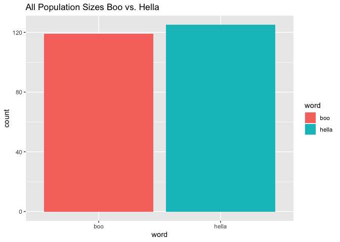

```r
pop_size <- hiphop %>%
  mutate(size = case_when(city < 10000 ~ "small", city <= 100000 ~ "medium", city > 100000 ~ "large")) %>%
  filter(word == "hella" | word == "boo") %>%
  arrange(desc(city)) %>%
  select(word, subj, city, size, fam1, familiarity)

# let's make a plot to see if "boo" or "hella" is more popular
pop_size %>%
  filter(fam1 == 1) %>%
  ggplot() +
  geom_bar(mapping = aes(x = word, fill = word)) +
  ggtitle("All Population Sizes Boo vs. Hella")
```

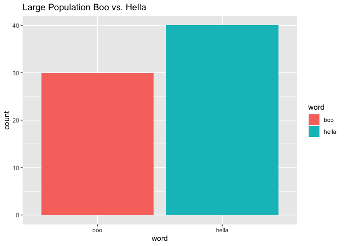

```r
# now let's plot to see which word is more popular among large cities
pop_size %>%
  filter(fam1 == 1) %>%
  filter(size == "large") %>%
  ggplot() +
  geom_bar(mapping = aes(x = word, fill = word)) +
  ggtitle("Large Population Boo vs. Hella")
```

Among all population sizes, the words “hella” and “boo” are fairly equal in familiarity, as seen in the first plot. In the second plot, we can see that the word “hella” is more familiar among large populations than the word “boo”.

Therefore, the title “Hella Bling” should appeal more to the higher population audience.

**3. Aubrey’s true life dream is to collaborate with his fellow Canadian musician Justin Bieber. Luckily, he knows that Bieber himself was one of the subjects in this study! You know that Bieber is a white male, aged 17-23 at the time of the study, from a relatively small town (10,000-60,000 people) in Ontario.**

**Determine which subject is secretly Bieber, and justify your answer.**

*Hint: Refer again to the dataset description. There is another clue about Bieber’s identity.*

```r
hiphop %>%
  select(subj, sex, age, ethnic, city, county, bieber) %>%
  unique() %>%
  filter(sex == "Male") %>%
  filter(age > 16) %>%
  filter(age < 24) %>%
  filter(ethnic == "white") %>%
  filter(city <= 60000) %>%
  filter(city >= 10000) %>%
  arrange(desc(bieber))
```

```
## # A tibble: 14 × 7
##    subj  sex     age ethnic  city  county bieber
##    <chr> <chr> <dbl> <chr>  <dbl>   <dbl>  <dbl>
##  1 p17   Male     18 white  56377  331582    5
##  2 p183  Male     21 white  59180  396500    2
##  3 p119  Male     18 white  24545   92107    2
##  4 p74   Male     19 white  24105   24106    2
##  5 p178  Male     20 white  23739   86311    2
##  6 p32   Male     18 white  50804 1156212    2
##  7 p180  Male     18 white  19657   62723    1.5
##  8 p169  Male     19 white  19657   62723    1
##  9 p138  Male     20 white  10465   50625    1
## 10 p55   Male     18 white  31008  331582    1
## 11 p28   Male     17 white  19391  396500    1
## 12 p121  Male     23 white  57345  231958    1
## 13 p148  Male     19 white  45561 1156212    1
## 14 p141  Male     18 white  33220  506278    1
```

I think Justin Bieber is subject p17. Of all the remaining subjects (white, male, age 17-23, from a small town), subject p17 had the highest “bieber” rating, of 5, while the others had a rating of 2 or below. We can assume that Justin Bieber would be able to list many of his own songs, and therefore have a high familiarity rating for the “bieber” section.